# Quelques préliminaires

## Vocabulaire

- Statistique : un *résumé* de l’information contenue dans l’ensemble des observation. Par exemple : la somme, la moyenne, l’écart-type, les quantiles…
- Description des données : un tableau peut être regardé comme un ensemble de lignes (des individus statistiques) ou comme un ensemble de colonnes (des variables).

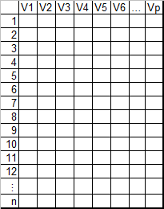

$\rightarrow$ structure du tableau (`dataframe`) à modifier ? Voir [le module sur la préparation des données](https://rawgit.com/MTES-MCT/parcours-r/master/Supports_formations/m2_preparer_ses_donnees_avec_R_et_le_tidyverse/_book/index.html)

## Données utilisées pour la formation

Nous utiliserons la base Insee de comparaison des territoires.

```r
dat <- read.csv (file = "Data/Base_synth_territoires.csv", sep = ';',
                 dec = ',', colClasses = c ("REG" = "factor"))
str (dat)  # premier aperçu de la base
```

```
## 'data.frame':    36689 obs. of  38 variables:
##  $ CODGEO       : Factor w/ 36689 levels "01001","01002",..: 1 2 3 4 5 6 7 8 9 10 ...
##  $ LIBGEO       : Factor w/ 34174 levels "Aast","Abainville",..: 13662 13664 439 441 456 476 480 576 633 796 ...
##  $ REG          : Factor w/ 17 levels "01","02","03",..: 15 15 15 15 15 15 15 15 15 15 ...
##  $ DEP          : Factor w/ 100 levels "01","02","03",..: 1 1 1 1 1 1 1 1 1 1 ...
##  $ ZAU          : Factor w/ 9 levels "111 - Grand pôle (plus de 10 000 emplois)",..: 3 2 2 2 8 2 2 5 8 2 ...
##  $ ZE           : Factor w/ 321 levels "0050 - Mont-de-Marsan",..: 260 248 248 260 263 248 248 263 266 250 ...
##  $ P14_POP      : int  767 239 14022 1627 109 2570 743 338 1142 397 ...
##  $ P09_POP      : int  787 207 13350 1592 120 2328 660 336 960 352 ...
##  $ SUPERF       : num  15.95 9.15 24.6 15.92 5.88 ...
##  $ NAIS0914     : int  40 16 1051 117 8 175 59 12 56 25 ...
##  $ DECE0914     : int  25 7 551 41 3 78 20 11 32 10 ...
##  $ P14_MEN      : num  306 99.3 6161.1 621.1 52.5 ...
##  $ NAISD15      : int  13 5 222 15 2 21 11 2 18 4 ...
##  $ DECESD15     : int  5 1 121 7 2 9 3 3 5 0 ...
```

[output cut: 24 more lines]

## Variables quantitatives

Une variable **quantitative** permet de mesurer une grandeur (quantité). Elle peut être :

- **discrète** (un nombre fini de valeurs possibles). *Exemple : un nombre de logements*
- **continue** (*a priori*, toutes les valeurs possibles). *Exemple : une taille, une surface, un revenu*

On peut calculer des statistiques (somme, moyenne, …) sur les variables quantitatives.

Dans R, il s’agit des variables de type `numeric`. Par exemple :

```r
v <- c (12.5, 25.38, 14.9)
class (v)
```

```
## [1] "numeric"
```

## Variables qualitatives

### Définition

Une variable **qualitative** indique des caractéristiques qui ne sont pas des quantités. Les différentes valeurs que peut prendre cette variable sont appelées les catégories ou modalités (`levels` dans R). Elle peut être :

- **ordonnée** (exprimer un ordre). *Exemple : “petit - moyen - grand”*
- **non ordonnée**. *Exemple : une couleur, un groupe sanguin…*

Une variable qualitative ne permet pas de faire des calculs (la moyenne d’un groupe sanguin n’a aucun sens)

Dans R, il s’agit des variables `factor`. Elles peuvent être générée par la fonction `factor()`. Par exemple :

```r
v <- factor (x = c ("un peu", "beaucoup", "passionnément", "un peu", "passionnément"))
paste ("v est de type (class) ", class (v))
```

```
## [1] "v est de type (class)  factor"
```

Les modalités de la variable sont appelées `levels`. On peut les obtenir grâce à la fonction `levels()`.

```r
levels (v)
```

```
## [1] "beaucoup"      "passionnément" "un peu"
```

```r
as.integer (v) %>% table ()
```

```
## .
## 1 2 3
## 1 2 2
```

Ce sont des étiquettes mais la variable est stockée sous forme d’entiers.

### Manipulation des `factor`

La manipulation des `factor` fait intervenir le package [`forcats`](https://cran.r-project.org/web/packages/forcats/forcats.pdf), de la librairie [`tidyverse`](https://www.tidyverse.org/), qui propose de nombreuses fonctions. Les fonctions de ce package sont reconnaissables à leur préfixe `fct_`. On peut trouver des exemples d’utilisation (en français) [ici](http://perso.ens-lyon.fr/lise.vaudor/manipulation-de-facteurs-avec-forcats/).

- Dans un dataframe contenant une variable de type `factor`, on filtre comme sur une chaîne de caractère :

```r
d <- filter (dat, substr (x = ZAU, start = 1, stop = 3) != "120")
# ou bien :
d <- filter (dat, ZAU != "111 - Grand pôle (plus de 10 000 emplois)")
```

- A la suite d’une opération de sélection des parmi les lignes, certains `levels` peuvent disparaître. Ils seront toutefois toujours présents dans la liste des modalités de la variables. `fct_drop()` permet de se débarasser des modalités désormais inutilisées.

```r
d %>% pull (ZAU) %>% levels ()
```

```
## [1] "111 - Grand pôle (plus de 10 000 emplois)"
## [2] "112 - Couronne d'un grand pôle"
## [3] "120 - Multipolarisée des grandes aires urbaines"
## [4] "211 - Moyen pôle (5 000 à 10 000 emplois)"
## [5] "212 - Couronne d'un moyen pôle"
## [6] "221 - Petit pôle (de 1 500 à 5 000 emplois)"
## [7] "222 - Couronne d'un petit pôle"
## [8] "300 - Autre commune multipolarisée"
## [9] "400 - Commune isolée hors influence des pôles"
```

```r
d %>% pull (ZAU) %>% fct_drop () %>% levels ()
```

```
## [1] "112 - Couronne d'un grand pôle"
## [2] "120 - Multipolarisée des grandes aires urbaines"
## [3] "211 - Moyen pôle (5 000 à 10 000 emplois)"
## [4] "212 - Couronne d'un moyen pôle"
## [5] "221 - Petit pôle (de 1 500 à 5 000 emplois)"
## [6] "222 - Couronne d'un petit pôle"
## [7] "300 - Autre commune multipolarisée"
## [8] "400 - Commune isolée hors influence des pôles"
```

La modalité “111 - Grand pôle (plus de 10 000 emplois)” a bien été supprimée.

- Les fonctions `levels()` et `fct_recode()` permettent de modifier les `levels`. La fonction `levels()` renomme toutes les modalités et s’applique sur un vecteur de type `factor`. `fct_recode()` permet de renommer seulement les `levels` voulus et peut être imbriqué dans un `mutate()`.

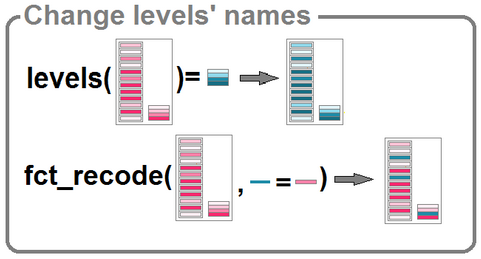

```r
vec_ZAU <- pull (dat, ZAU)
levels(vec_ZAU) <- c("111 - Grand pôle",
                     "112 - Couronne GP",
                     "120 - Multipol grandes AU",
                     "211 - Moyen pôle",
                     "212 - Couronne MP" ,
                     "221 - Petit pôle",
                     "222 - Couronne PP",
                     "300 - Autre multipol.",
                     "400 - Commune isolée")
dat$ZAU2 <- vec_ZAU
levels (vec_ZAU)
```

```
## [1] "111 - Grand pôle"          "112 - Couronne GP"
## [3] "120 - Multipol grandes AU" "211 - Moyen pôle"
## [5] "212 - Couronne MP"         "221 - Petit pôle"
## [7] "222 - Couronne PP"         "300 - Autre multipol."
## [9] "400 - Commune isolée"
```

```r
dat <- dat %>%
  mutate (DEP2 = fct_recode (DEP, "Ain" = "01", "Aisne" = "02"))
```

- Pour agréger des facteurs et compter le nombre de modalités, on peut se servir de `fct_count()` :

```r
pull (dat, ZAU2) %>%
  fct_recode (urbain = "111 - Grand pôle", urbain = "211 - Moyen pôle",
              urbain = "221 - Petit pôle",
              periurbain = "112 - Couronne GP", periurbain = "212 - Couronne MP",
              periurbain = "120 - Multipol grandes AU", periurbain = "300 - Autre multipol.",
              periurbain = "222 - Couronne PP",
              rural = "400 - Commune isolée") %>%
  fct_count ()
```

```
## # A tibble: 3 x 2
##   f              n
##   <fct>      <int>
## 1 urbain      4629
## 2 periurbain 24677
## 3 rural       7383
```

- Pour modifier l’ordre des facteurs (cela peut être utile en particulier pour les représentations graphiques), il existe plusieurs fonctions :

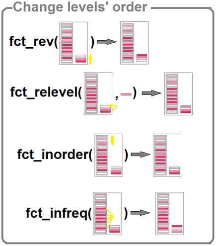

```r
# renverser l'ordre
dat <- dat %>%
  mutate (ZAU3 = fct_rev (ZAU2))

# ordonner "à la main"
dat <- dat %>%
  mutate (ZAU3 = fct_relevel (ZAU2, "221 - Petit pôle", "111 - Grand pôle"))

# ordonner selon ordre d'apparition
dat <- dat %>%
  mutate (ZAU3 = fct_inorder (ZAU2))

# ordonner selon la fréquence
dat <- dat %>%
  mutate (ZAU3 = fct_infreq (ZAU2))
```